# Prosper Loan Data Exploration

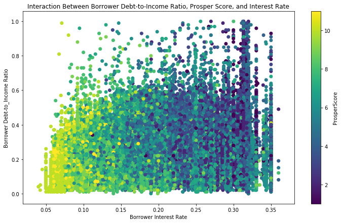

```python
plt.figure(figsize = (12, 7))
plt.scatter(data = df_loan4, x = 'BorrowerRate', y = 'DebtToIncomeRatio', c = 'ProsperScore' )
plt.colorbar(label = 'ProsperScore')
plt.xlabel('Borrower Interest Rate')
plt.ylabel('Borrower Debt-to_Income Ratio')
plt.title('Interaction Between Borrower Debt-to-Income Ratio, Prosper Score, and Interest Rate');
```

When having explored the original loan amount and scheduled monthly payment individually versus the loan status, there did not appear to be any indication of an increased risk. However, the following scatterplot looking at the interaction of both the original loan amount and monthly scheduled payment demonstrates that as the monthly payment goes up, there appear to be some clusters of the data indicating some increased risk as noted by the darker green circles. The frequency of these small clusters increases somewhat as the original loan amount goes up, up to around the $25k mark.

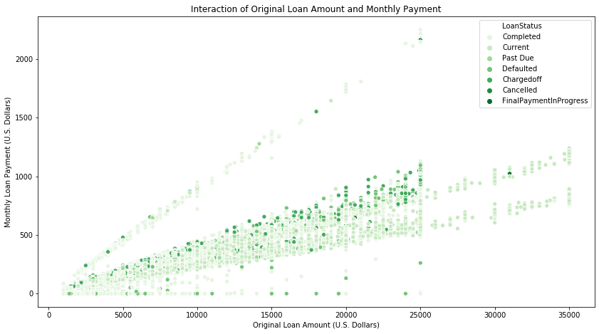

```python
plt.figure(figsize = ( 14, 7.5))
sn.scatterplot(data = df_loan, x = 'LoanOriginalAmount', y=  'MonthlyLoanPayment', hue = 'LoanStatus', palette = 'Greens')
plt.xlabel('Original Loan Amount (U.S. Dollars)')
plt.ylabel('Monthly Loan Payment (U.S. Dollars)')
plt.title('Interaction of Original Loan Amount and Monthly Payment');
```

The following facet grid of histograms demonstrates that higher incomes tend to be associated with higher Prosper scores and lower interest rates. The $50k - $75k and the $75k - $100k income ranges seem to represent many borrowers with high Prosper scores and lower interests' rates as indicated by the darkened green area. We begin to see a shift in the pattern at $25k - $50k income range and lower.

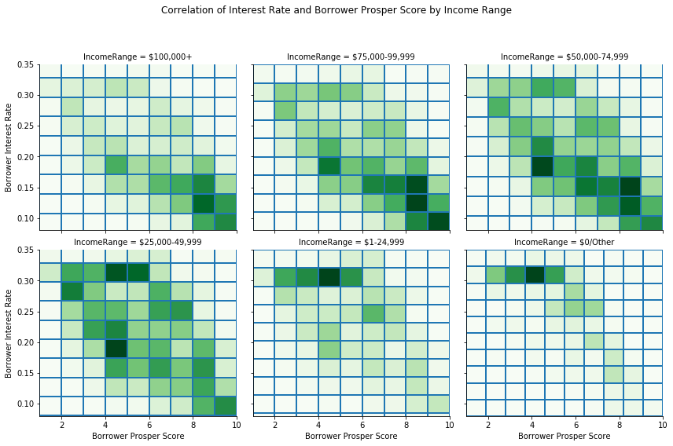

```python
g = sn.FacetGrid(data = df_loan, col = 'IncomeRange', col_wrap = 3, height = 4)
g.map(plt.hist2d, 'ProsperScore', 'BorrowerRate', cmap = 'Greens')
g.set_axis_labels(x_var = 'Borrower Prosper Score', y_var = 'Borrower Interest Rate');
g.fig.suptitle('Correlation of Interest Rate and Borrower Prosper Score by Income Range')
g.fig.subplots_adjust(top = 0.85);
```

In looking at the following facet grid of histograms, the darker regions indicate a larger concentration of borrowers with higher Prosper scores and lower interests’ rates were more likely to have current and or completed loans. We can see a shift in the patter in loans that are past due. For loans that are defaulted or charged off we see that there is a concentration of borrower's that have lower Prosper scores in combination with higher interests' rates. This demonstrates that higher interests' rates coupled with lower Prosper scores may present an increased risk for Prosper.

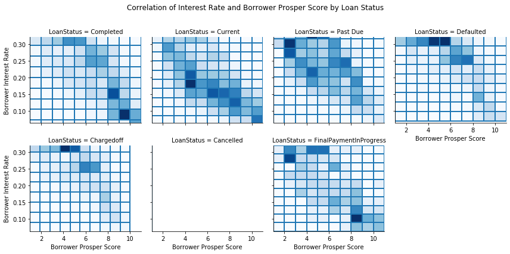

```python
g1 = sn.FacetGrid(data = df_loan, col = 'LoanStatus', col_wrap = 4, height = 3)
g1.map(plt.hist2d, 'ProsperScore', 'BorrowerRate', cmap = 'Blues')
g1.set_axis_labels(x_var = 'Borrower Prosper Score', y_var = 'Borrower Interest Rate');
g1.fig.suptitle('Correlation of Interest Rate and Borrower Prosper Score by Loan Status')
g1.fig.subplots_adjust(top = 0.85);
```

The following heatmap shows that higher income levels along with lower median interest rates appear to be more favorable for positive loan outcomes. We can see there is a trend towards negative loan outcomes as the median interests' rate goes up along with lower income. The combination of lower income coupled with higher interests' rates indicate an increased risk of borrowers not being able to repay the lender.

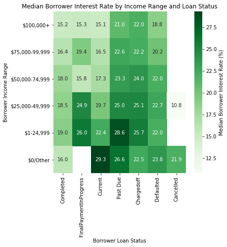

```python
cat_counts = df_loan.groupby(['LoanStatus', 'IncomeRange']).median()['BorrowerRate'] * 100
cat_counts = cat_counts.reset_index(name = 'MedianBorrowerRate')
cat_counts = cat_counts.pivot(index = 'IncomeRange',columns = 'LoanStatus', values = 'MedianBorrowerRate')

plt.figure(figsize = (6, 6))
sn.heatmap(cat_counts, annot = True, cmap = 'Greens', fmt = '.1f', cbar_kws = {'label': 'Median Borrower Interest Rate (%)'})
plt.ylabel('Borrower Income Range')
plt.xlabel('Borrower Loan Status')
plt.title('Median Borrower Interest Rate by Income Range and Loan Status');
```

Being that Prosper scores and interests' rates have a solid moderate negative correlation, we see a similar pattern in the following heatmap in which higher incomes along with higher Prosper scores are favorable for positive loan outcomes. We see an unfavorable trend as both Prosper scores and income levels drop. Borrowers with higher credit ratings, lower interests' rates, and higher incomes may in fact pose a reduced risk for lenders.

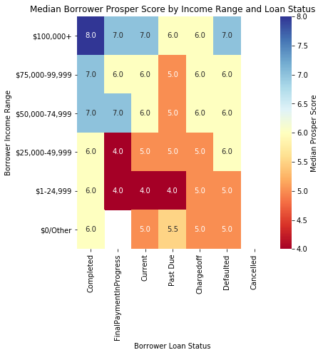

```python
cat_counts2 = df_loan.groupby(['LoanStatus', 'IncomeRange']).median()['ProsperScore'] * 1
cat_counts2 = cat_counts2.reset_index(name = 'MedianProsperScore')
cat_counts2 = cat_counts2.pivot(index = 'IncomeRange',columns = 'LoanStatus', values = 'MedianProsperScore')

plt.figure(figsize = (6, 6))
sn.heatmap(cat_counts2, annot = True, cmap = 'RdYlBu', fmt = '.1f', cbar_kws = {'label': 'Median Prosper Score'})
plt.ylabel('Borrower Income Range')
plt.xlabel('Borrower Loan Status')
plt.title('Median Borrower Prosper Score by Income Range and Loan Status');
```